# Article - Sentiment d’appartenance

Thea

2023-05-17

```r
library(summarytools)
library(tidyverse)
library(ggthemes)
library(haven)
Base_Trajipaq_Finale_Ok <- read_dta("C:/Users/Théo CARLIER/OneDrive/Bureau/Base_Trajipaq_Finale_Ok.dta")
```

# Question de recherche : de quelles façons les discriminations que subissent les personnes immigrantes influencent leur sentiment d’appartenance au Québec ?

## Variable indépendante = Les discriminations que subissent les personnes immigrantes :

- dans l’emploi
- dans la recherche de logement
- dans la santé
- sur le lieu de formation

Type de variable = factoriel Niveau de mesure = ordinal (échelle de Likert)

Réponses possibles :

1. Tout à fait d’accord
2. Plutôt d’accord
3. Plutôt pas d’accord
4. Pas du tout d’accord
5. Je ne sais pas
6. Je ne préfère pas répondre

## Variable dépendante = le sentiment d’appartenance au Québec :

- se sentir chez soi au Québec
- la nécessité d’oublier sa culture d’origine pour s’intégrer au Québec
- être vu(e) comme un(e) Québécois(e)
- se sentir Québécois(e)
- se sentir Canadien(ne)
- avoir un sentiment d’appartenance avec son pays d’origine

Type de variable = factoriel Niveau de mesure = ordinal (échelle de Likert)

Réponses possibles :

1. Tout à fait d’accord
2. Plutôt d’accord
3. Plutôt pas d’accord
4. Pas du tout d’accord
5. Je ne sais pas
6. Je ne préfère pas répondre

## Variables de contrôle = caractéristiques sociodémographiques :

- sexe
- groupe d’âge
- statut matrimonial
- pays d’origine
- statut d’immigration au Québec
- statut d’immigration pré-résidence
- niveau d’éducation
- religion
- compétence linguistique (français)
- compétence linguistique (anglais)
- état de santé actuel
- état de santé depuis 12 mois
- niveau d’éducation de la mère
- niveau d’éducation du père

# Présentation des variables de contrôle

## Q10. Êtes-vous un homme, une femme ou autre ?

1. Homme
2. Femme
3. Autre

Type de variable = catégorielle Niveau de mesure = nominal

```r
Base_Trajipaq_Finale_Ok <-
  Base_Trajipaq_Finale_Ok %>%
  mutate(Q10_F = case_when(
    Q10 == 1 ~ "Homme",
    Q10 == 2 ~ "Femme",
    Q10 == 97 ~ "Autre"
  ))
```

```r
freq(Base_Trajipaq_Finale_Ok$Q10_F)
```

```
## Frequencies
## Base_Trajipaq_Finale_Ok$Q10_F
## Type: Character
##
##               Freq   % Valid   % Valid Cum.   % Total   % Total Cum.
## ----------- ------ --------- -------------- --------- --------------
##       Femme    886     56.69          56.69     56.69          56.69
##       Homme    677     43.31         100.00     43.31         100.00
##        <NA>      0                               0.00         100.00
##       Total   1563    100.00         100.00    100.00         100.00
```

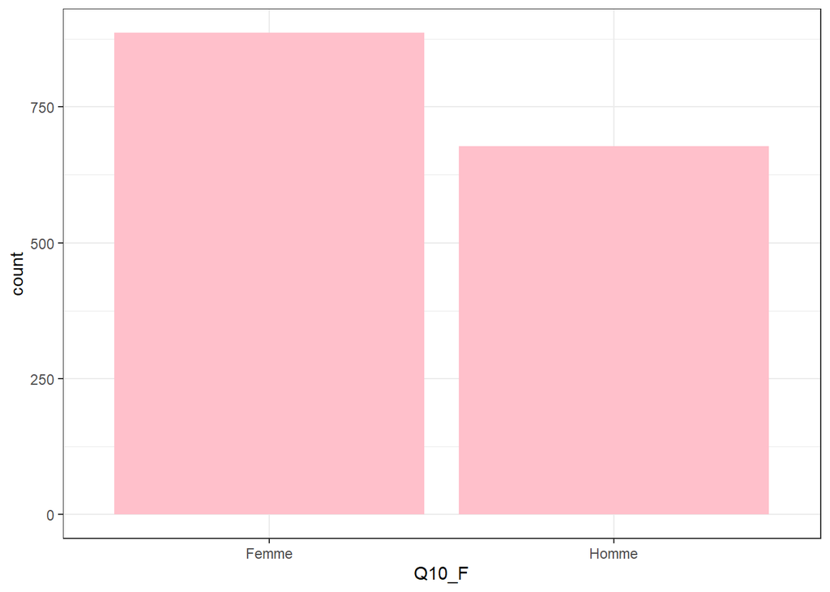

```r
ggplot(data = Base_Trajipaq_Finale_Ok, mapping = aes(x = Q10_F)) +
  geom_bar(fill = "pink") +
  theme_bw()
```

La réponse modale est “femme” (56.69%).

## Q8B A quel groupe d’âge appartenez-vous ?

1. 0 – 19 ans
2. 20 – 24 ans
3. 25 – 29 ans
4. 30 – 34 ans
5. 35 – 39 ans
6. 40 – 44 ans
7. 45 – 49 ans
8. 50 – 60 ans
9. 61 ans et plus
10. Je préfère ne pas répondre

Type de variable = factoriel Niveau de mesure = ordinal

```r
freq(Base_Trajipaq_Finale_Ok$QAGE)
```

```
## Frequencies
## Base_Trajipaq_Finale_Ok$QAGE
## Label: Vous appartenez à quel groupe d’âge?
## Type: Numeric
##
##               Freq   % Valid   % Valid Cum.   % Total   % Total Cum.
## ----------- ------ --------- -------------- --------- --------------
##           2     76      4.86           4.86      4.86           4.86
##           3    136      8.70          13.56      8.70          13.56
##           4    259     16.57          30.13     16.57          30.13
##           5    385     24.63          54.77     24.63          54.77
##           6    328     20.99          75.75     20.99          75.75
##           7    182     11.64          87.40     11.64          87.40
##           8    125      8.00          95.39      8.00          95.39
##           9     72      4.61         100.00      4.61         100.00
##        <NA>      0                               0.00         100.00
##       Total   1563    100.00         100.00    100.00         100.00
```

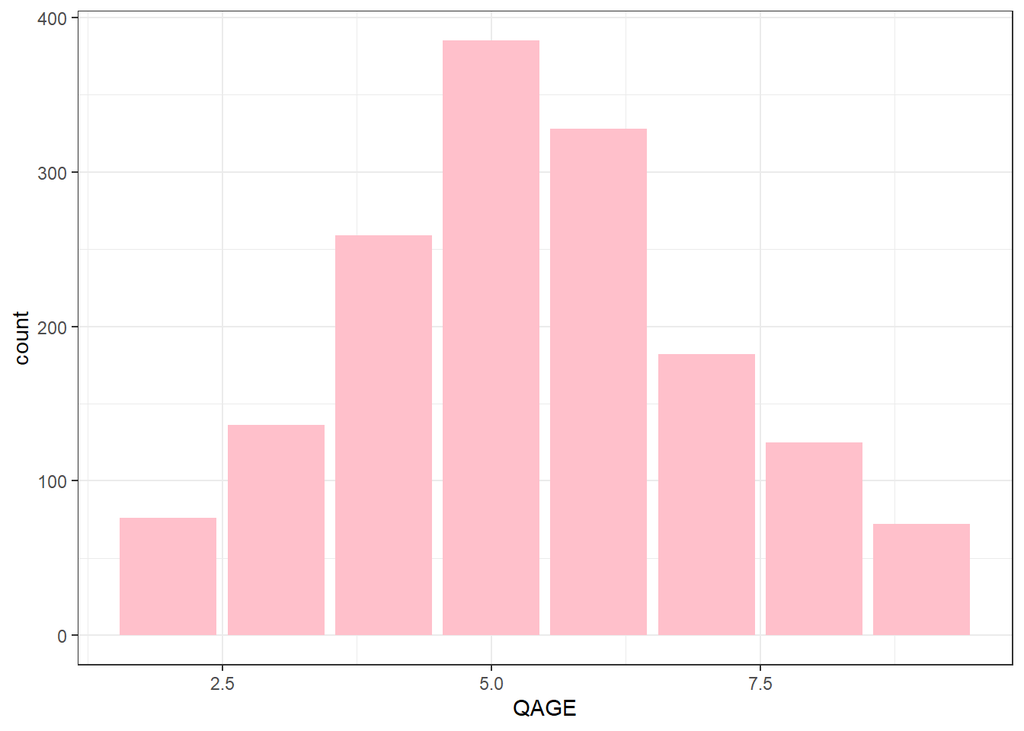

```r
ggplot(data = Base_Trajipaq_Finale_Ok, mapping = aes(x = QAGE)) +
  geom_bar(fill = "pink", na.rm = TRUE) +
  theme_bw()
```

La distribution est symétrique. Le groupe d’âge modal est “35-39 ans” (24.63%).

## STATUT. Êtes-vous actuellement… ?

1. Célibataire/jamais marié(e) ou conjoint(e) de fait
2. Marié(e)
3. Conjoint(e) de fait/en union libre
4. Séparé(e)
5. Divorcé(e)
6. Veuf(ve)

Type de variable = catégorielle Niveau de mesure = nominal

```r
freq(Base_Trajipaq_Finale_Ok$STATUT)
```

```
## Frequencies
## Base_Trajipaq_Finale_Ok$STATUT
## Label: Êtes-vous actuellement...?
## Type: Numeric
##
##               Freq   % Valid   % Valid Cum.   % Total   % Total Cum.
## ----------- ------ --------- -------------- --------- --------------
##           1    363     24.26          24.26     23.22          23.22
##           2    711     47.53          71.79     45.49          68.71
##           3    331     22.13          93.92     21.18          89.89
##           4     39      2.61          96.52      2.50          92.39
##           5     46      3.07          99.60      2.94          95.33
##           6      6      0.40         100.00      0.38          95.71
##        <NA>     67                               4.29         100.00
##       Total   1563    100.00         100.00    100.00         100.00
```

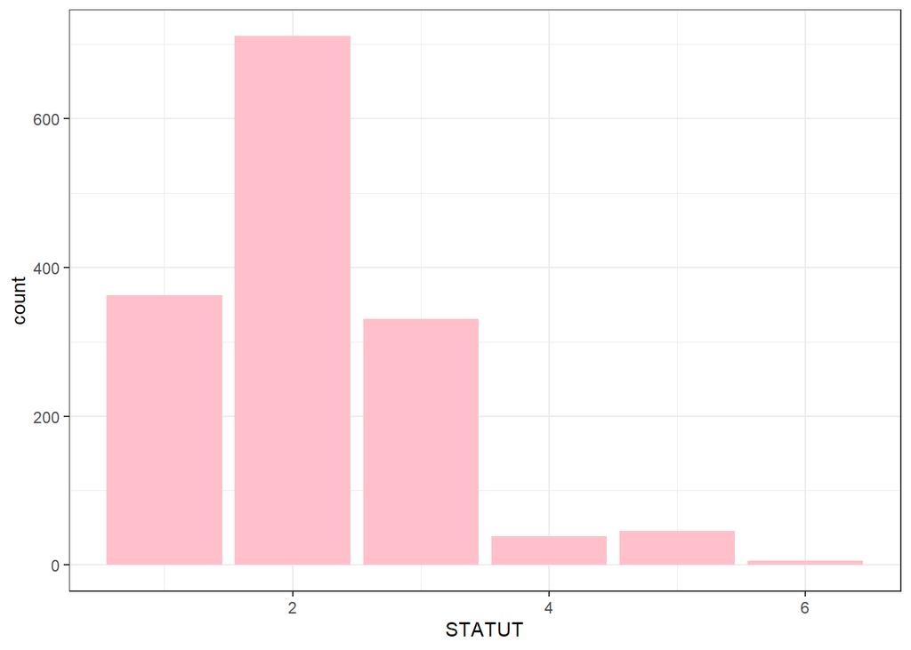

```r
ggplot(data = Base_Trajipaq_Finale_Ok, mapping = aes(x = STATUT)) +
  geom_bar(fill = "pink", na.rm = TRUE) +
  theme_bw()
```

La réponse modale est “Marié(e)” (47.53%)

## Q11. Dans quel pays êtes-vous né ?

Pays. (liste déroulante) 998. Je ne sais pas 999. Je préfère ne pas répondre

Type de variable = catégorielle Niveau de mesure = nominal

```r
freq(Base_Trajipaq_Finale_Ok$Q11)
```

```
## Frequencies
## Base_Trajipaq_Finale_Ok$Q11
## Label: Dans quel pays êtes-vous né(e) ?Si vous ne vous en souvenez pas, inscrire : « Je
## Type: Numeric
##
##               Freq   % Valid   % Valid Cum.   % Total   % Total Cum.
## ----------- ------ --------- -------------- --------- --------------
##           2      1     0.090          0.090     0.064          0.064
##           4      1     0.090          0.180     0.064          0.128
##           5     74     6.649          6.828     4.734          4.862
##           6      6     0.539          7.367     0.384          5.246
##          12      2     0.180          7.547     0.128          5.374
##          13      8     0.719          8.266     0.512          5.886
##          14      1     0.090          8.356     0.064          5.950
##          16      2     0.180          8.535     0.128          6.078
```

[output cut: 99 more lines]

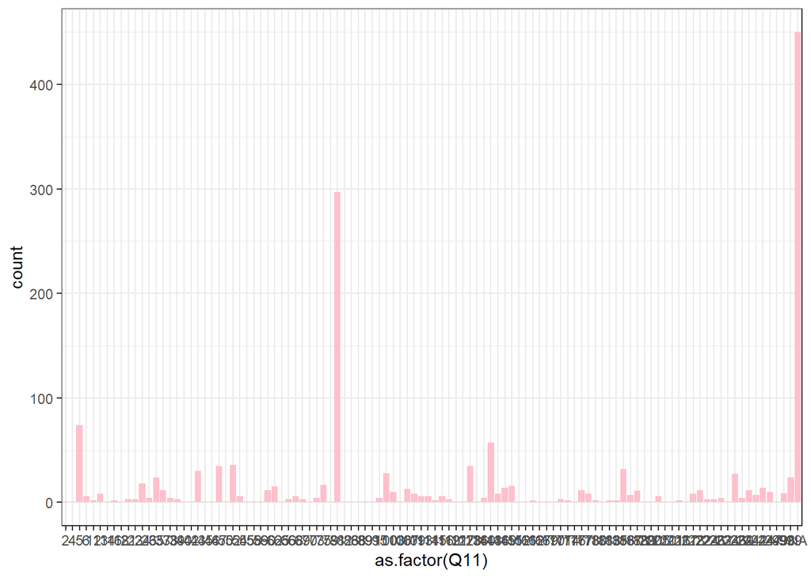

```r
ggplot(data = Base_Trajipaq_Finale_Ok, mapping = aes(x = as.factor(Q11))) +
  geom_bar(fill = "pink") +
  theme_bw()
```

Les réponses modales sont “France” (26.685%) et “Algérie” (6.649%).

## Q4. Êtes-vous né au Canada ?

Type de variable = catégoriel Niveau de mesure = nominal

```r
freq(Base_Trajipaq_Finale_Ok$Q4)
```

```
## Frequencies
## Base_Trajipaq_Finale_Ok$Q4
## Label: Êtes-vous né(e) au Canada ?
## Type: Numeric
##
##               Freq   % Valid   % Valid Cum.   % Total   % Total Cum.
## ----------- ------ --------- -------------- --------- --------------
##           1   1113     71.21          71.21     71.21          71.21
##           2    450     28.79         100.00     28.79         100.00
##        <NA>      0                               0.00         100.00
##       Total   1563    100.00         100.00    100.00         100.00
```

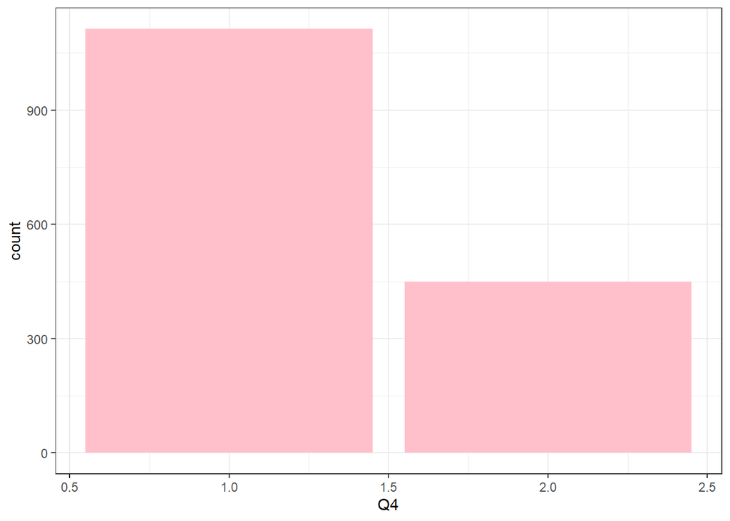

```r
ggplot(data = Base_Trajipaq_Finale_Ok, mapping = aes(x = Q4)) +
  geom_bar(fill = "pink", na.rm = TRUE) +
  theme_bw()
```

## Q15I. Statut migratoire avant d’obtenir la résidence permanente

1. Travailleur temporaire (visa de travail ou permis de travail)
2. Demandeur d’asile
3. Étudiant étranger (visa d’études)
4. Touriste
5. Autre
6. Je ne sais pas
7. Je préfère ne pas répondre

Type de variable = catégoriel Niveau de mesure = nominal

```r
Base_Trajipaq_Finale_Ok <-
  Base_Trajipaq_Finale_Ok %>%
  mutate(Q15M1 = case_when(
    Q15M1 == 1 ~ 1,
    Q15M1 == 2 ~ 2,
    Q15M1 == 3 ~ 3,
    Q15M1 == 4 ~ 4,
    Q15M1 == 97 ~ 5,
    Q15M1 == 98 ~ NA,
    Q15M1 == 99 ~ NA
  ))
```

```r
freq(Base_Trajipaq_Finale_Ok$Q15M1)
```

```
## Frequencies
## Base_Trajipaq_Finale_Ok$Q15M1
## Type: Numeric
##
##               Freq   % Valid   % Valid Cum.   % Total   % Total Cum.
## ----------- ------ --------- -------------- --------- --------------
##           1    241     57.79          57.79     15.42          15.42
##           2     14      3.36          61.15      0.90          16.31
##           3     82     19.66          80.82      5.25          21.56
##           4     35      8.39          89.21      2.24          23.80
##           5     45     10.79         100.00      2.88          26.68
##        <NA>   1146                              73.32         100.00
##       Total   1563    100.00         100.00    100.00         100.00
```

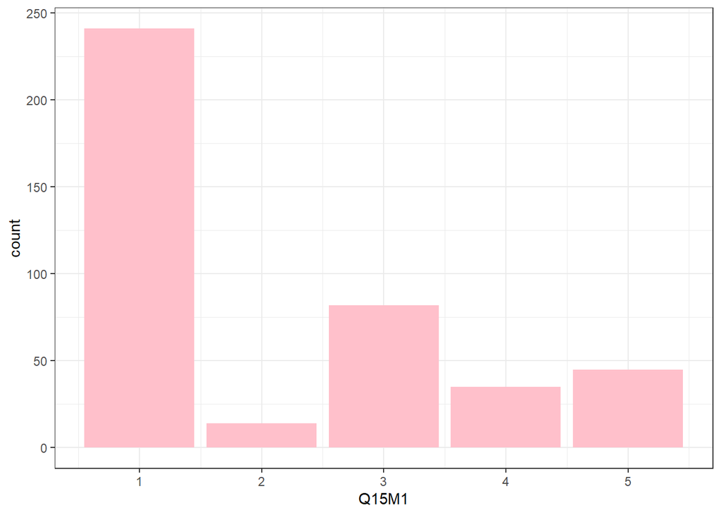

```r
ggplot(data = Base_Trajipaq_Finale_Ok, mapping = aes(x = Q15M1)) +
  geom_bar(fill = "pink", na.rm = TRUE) +
  theme_bw()
```

La réponse modale est “travailleur temporaire” (57.78%).

## Q16. Quel est votre plus haut diplôme d’études obtenu ?

1. Moins que le secondaire
2. Secondaire ou équivalent
3. Collégial
4. Formation professionnelle ou post-secondaire
5. Université 1er cycle
6. Université 2ème cycle et plus
7. Je ne sais pas
8. Je préfère ne pas répondre

Type de variable = factorielle Niveau de mesure = ordinal

```r
Base_Trajipaq_Finale_Ok <-
  Base_Trajipaq_Finale_Ok %>%
  mutate(Q16 = case_when(
    Q16 == 1 ~ 1,
    Q16 == 2 ~ 2,
    Q16 == 3 ~ 3,
    Q16 == 4 ~ 4,
    Q16 == 5 ~ 5,
    Q16 == 6 ~ 6,
    Q16 == 98 ~ NA,
    Q16 == 99 ~ NA
  ))
```

```r
freq(Base_Trajipaq_Finale_Ok$Q16)
```

```
## Frequencies
## Base_Trajipaq_Finale_Ok$Q16
## Type: Numeric
##
##               Freq   % Valid   % Valid Cum.   % Total   % Total Cum.
## ----------- ------ --------- -------------- --------- --------------
##           1     11      0.71           0.71      0.70           0.70
##           2    101      6.51           7.22      6.46           7.17
##           3    254     16.38          23.60     16.25          23.42
##           4    141      9.09          32.69      9.02          32.44
##           5    520     33.53          66.22     33.27          65.71
##           6    524     33.78         100.00     33.53          99.23
##        <NA>     12                               0.77         100.00
##       Total   1563    100.00         100.00    100.00         100.00
```

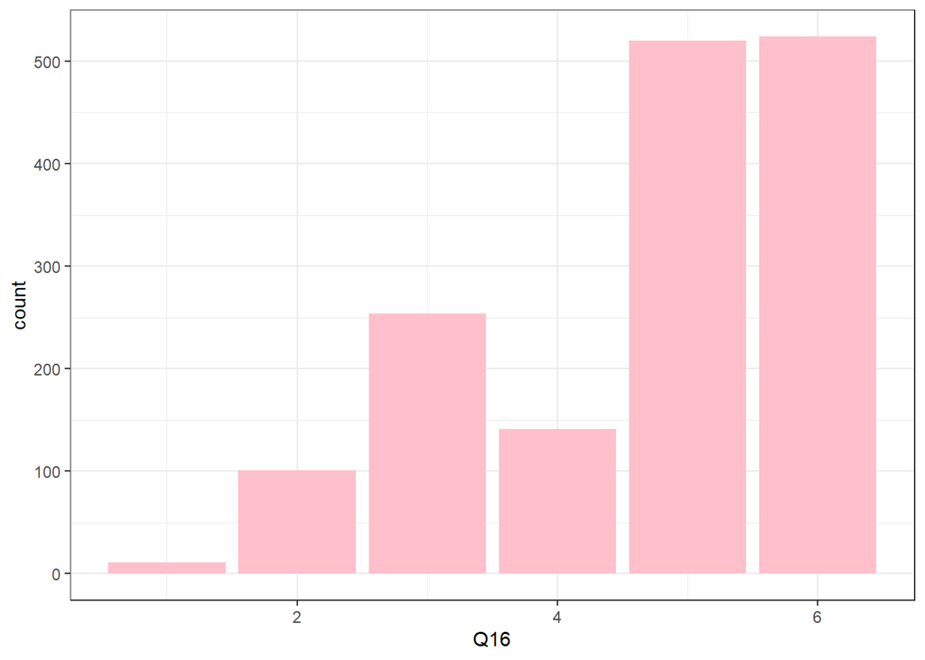

```r
ggplot(data = Base_Trajipaq_Finale_Ok, mapping = aes(x = Q16)) +
  geom_bar(fill = "pink", na.rm = TRUE) +
  theme_bw()
```

La distribution du niveau d’éducation est asymétrique vers la gauche. L’échantillon est composé à 67.31% de personnes titulaires d’un diplôme universitaire.

## Q17. Actuellement, avez-vous une religion ?

0. Sans religion
1. Catholique
2. Protestante
3. Évangéliste
4. Mormone
5. Témoins de Jéhovah
6. Orthodoxe
7. Autres Chrétiens
8. Musulmans
9. Juif
10. Bouddhiste
11. Hindou
12. Animiste
13. Autre
14. Je ne sais pas
15. Je préfère ne pas répondre

Type de variable = catégorielle Niveau de mesure = nominal

```r
Base_Trajipaq_Finale_Ok <-
  Base_Trajipaq_Finale_Ok %>%
  mutate(Q17 = case_when(
    Q17 == 0 ~ 0,
    Q17 == 1 ~ 1,
    Q17 == 2 ~ 2,
    Q17 == 3 ~ 3,
    Q17 == 4 ~ 4,
    Q17 == 5 ~ 5,
    Q17 == 6 ~ 6,
    Q17 == 7 ~ 7,
    Q17 == 8 ~ 8,
    Q17 == 9 ~ 9,
    Q17 == 10 ~ 10,
    Q17 == 11 ~ 11,
    Q17 == 12 ~ 12,
    Q17 == 97 ~ 13,
    Q17 == 98 ~ NA,
    Q17 == 99 ~ NA
  ))
```

```r
freq(Base_Trajipaq_Finale_Ok$Q17)
```

```
## Frequencies
## Base_Trajipaq_Finale_Ok$Q17
## Type: Numeric
##
##               Freq   % Valid   % Valid Cum.   % Total   % Total Cum.
## ----------- ------ --------- -------------- --------- --------------
##           0    552     36.36          36.36     35.32          35.32
##           1    489     32.21          68.58     31.29          66.60
##           2     42      2.77          71.34      2.69          69.29
##           3     23      1.52          72.86      1.47          70.76
##           4      2      0.13          72.99      0.13          70.89
##           5      5      0.33          73.32      0.32          71.21
##           6     89      5.86          79.18      5.69          76.90
##           7     17      1.12          80.30      1.09          77.99
##           8    210     13.83          94.14     13.44          91.43
##           9     18      1.19          95.32      1.15          92.58
##          10     22      1.45          96.77      1.41          93.99
##          11     11      0.72          97.50      0.70          94.69
##          12      2      0.13          97.63      0.13          94.82
##          13     36      2.37         100.00      2.30          97.12
##        <NA>     45                               2.88         100.00
##       Total   1563    100.00         100.00    100.00         100.00
```

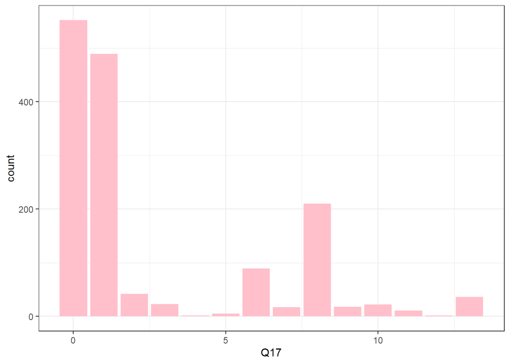

```r
ggplot(data = Base_Trajipaq_Finale_Ok, mapping = aes(x = Q17)) +
  geom_bar(fill = "pink", na.rm = TRUE) +
  theme_bw()
```

Les réponses modales sont “sans religion” (36.36%) et “catholique” (32.21%). On remarque également un nombre significatif de réponses “musulman” (13.83%).

## Q20. Quand vous étiez enfant, quelles étaient la langue ou les langues que vous parliez le plus souvent, à l’âge de 5 ans et que vous comprenez toujours? (Plusieurs réponses possibles).

1. Français
2. Anglais
3. Autre : préciser, possibilité d’en déclarer deux
4. Je ne sais pas
5. Je préfère ne pas répondre

Type de variable = catégoriel Niveau de mesure = nominal

```r
Base_Trajipaq_Finale_Ok <-
  Base_Trajipaq_Finale_Ok %>%
  mutate(Q20M1 = case_when(
    Q20M1 == 1 ~ 1,
    Q20M1 == 2 ~ 2,
    Q20M1 == 97 ~ 3,
    Q20M1 == 98 ~ NA,
    Q20M1 == 99 ~ NA
  ))
```

```r
freq(Base_Trajipaq_Finale_Ok$Q20M1)
```

```
## Frequencies
## Base_Trajipaq_Finale_Ok$Q20M1
## Type: Numeric
##
##               Freq   % Valid   % Valid Cum.   % Total   % Total Cum.
## ----------- ------ --------- -------------- --------- --------------
##           1    987     63.84          63.84     63.15          63.15
##           2    129      8.34          72.19      8.25          71.40
##           3    430     27.81         100.00     27.51          98.91
##        <NA>     17                               1.09         100.00
##       Total   1563    100.00         100.00    100.00         100.00
```

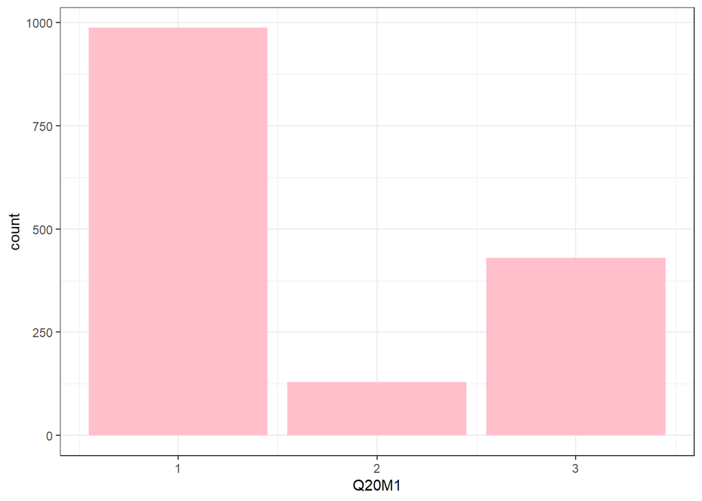

```r
ggplot(data = Base_Trajipaq_Finale_Ok, mapping = aes(x = Q20M1)) +
  geom_bar(fill = "pink", na.rm = TRUE) +
  theme_bw()
```

La réponse modale est “français” (63.84%).

## I3. Indice de la compétence linguistique (français)

Type de variable = numeric Niveau de mesure = ratio

```r
Base_Trajipaq_Finale_Ok <-
  Base_Trajipaq_Finale_Ok %>%
  mutate(Q21A = case_when(
    Q21A == 1 ~ 1,
    Q21A == 2 ~ 2,
    Q21A == 3 ~ 3,
    Q21A == 4 ~ 4,
    Q21A == 98 ~ NA,
    Q21A == 99 ~ NA
  ))

Base_Trajipaq_Finale_Ok <-
  Base_Trajipaq_Finale_Ok %>%
  mutate(Q21B = case_when(
    Q21B == 1 ~ 1,
    Q21B == 2 ~ 2,
    Q21B == 3 ~ 3,
    Q21B == 4 ~ 4,
    Q21B == 98 ~ NA,
    Q21B == 99 ~ NA
  ))

Base_Trajipaq_Finale_Ok <-
  Base_Trajipaq_Finale_Ok %>%
  mutate(Q21C = case_when(
    Q21C == 1 ~ 1,
    Q21C == 2 ~ 2,
    Q21C == 3 ~ 3,
    Q21C == 4 ~ 4,
    Q21C == 98 ~ NA,
    Q21C == 99 ~ NA
  ))

Base_Trajipaq_Finale_Ok <-
  Base_Trajipaq_Finale_Ok %>%
  mutate(Q21D = case_when(
    Q21D == 1 ~ 1,
    Q21D == 2 ~ 2,
    Q21D == 3 ~ 3,
    Q21D == 4 ~ 4,
    Q21D == 98 ~ NA,
    Q21D == 99 ~ NA
  ))
```

```r
v_I3 <- c("Q21A",
          "Q21B",
          "Q21C",
          "Q21D"
          )

Base_Trajipaq_Finale_Ok <-
  Base_Trajipaq_Finale_Ok %>%
  rowwise() %>%
  mutate(I3 = (sum(c_across(all_of(v_I3)), na.rm = TRUE) - length(v_I3)) / (3*length(v_I3))) %>%
  mutate(I3 = if (I3 < 0) NA_real_ else I3) %>%
  ungroup()
```

```r
descr(Base_Trajipaq_Finale_Ok$I3)
```

```
## Descriptive Statistics
## Base_Trajipaq_Finale_Ok$I3
## N: 1563
##
##                          I3
## ----------------- ---------
##              Mean      0.87
##           Std.Dev      0.24
##               Min      0.00
##                Q1      0.83
##            Median      1.00
##                Q3      1.00
##               Max      1.00
##               MAD      0.00
##               IQR      0.17
##                CV      0.28
##          Skewness     -1.98
##       SE.Skewness      0.07
##          Kurtosis      3.23
##           N.Valid   1117.00
##         Pct.Valid     71.47
```

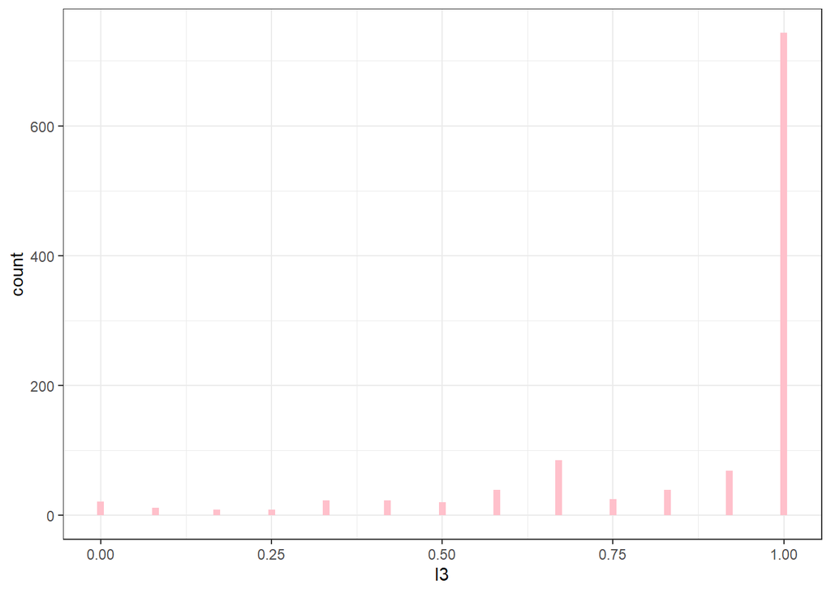

```r
ggplot(data = Base_Trajipaq_Finale_Ok, mapping = aes(x = I3)) +
  geom_histogram(na.rm = TRUE, fill = "pink", binwidth = 0.01) +
  theme_bw()
```

La distribution est asymétrique vers la gauche. L’indice moyen de maîtrise du français est 0.87.

## I4. Indice de la compétence linguistique (anglais).

Type de variable = numeric Niveau de mesure = ratio

```r
Base_Trajipaq_Finale_Ok <-
  Base_Trajipaq_Finale_Ok %>%
  mutate(Q22A = case_when(
    Q22A == 1 ~ 1,
    Q22A == 2 ~ 2,
    Q22A == 3 ~ 3,
    Q22A == 4 ~ 4,
    Q22A == 98 ~ NA,
    Q22A == 99 ~ NA
  ))

Base_Trajipaq_Finale_Ok <-
  Base_Trajipaq_Finale_Ok %>%
  mutate(Q22B = case_when(
    Q22B == 1 ~ 1,
    Q22B == 2 ~ 2,
    Q22B == 3 ~ 3,
    Q22B == 4 ~ 4,
    Q22B == 98 ~ NA,
    Q22B == 99 ~ NA
  ))

Base_Trajipaq_Finale_Ok <-
  Base_Trajipaq_Finale_Ok %>%
  mutate(Q22C = case_when(
    Q22C == 1 ~ 1,
    Q22C == 2 ~ 2,
    Q22C == 3 ~ 3,
    Q22C == 4 ~ 4,
    Q22C == 98 ~ NA,
    Q22C == 99 ~ NA
  ))

Base_Trajipaq_Finale_Ok <-
  Base_Trajipaq_Finale_Ok %>%
  mutate(Q22D = case_when(
    Q22D == 1 ~ 1,
    Q22D == 2 ~ 2,
    Q22D == 3 ~ 3,
    Q22D == 4 ~ 4,
    Q22D == 98 ~ NA,
    Q22D == 99 ~ NA
  ))
```

```r
v_I4 <- c("Q22A",
          "Q22B",
          "Q22C",
          "Q22D"
          )

Base_Trajipaq_Finale_Ok <-
  Base_Trajipaq_Finale_Ok %>%
  rowwise() %>%
  mutate(I4 = (sum(c_across(all_of(v_I4)), na.rm = TRUE) - length(v_I4)) / (3*length(v_I4))) %>%
  mutate(I4 = if (I4 < 0) NA_real_ else I4) %>%
  ungroup()
```

```r
descr(Base_Trajipaq_Finale_Ok$I4)
```

```
## Descriptive Statistics
## Base_Trajipaq_Finale_Ok$I4
## N: 1563
##
##                          I4
## ----------------- ---------
##              Mean      0.73
##           Std.Dev      0.29
##               Min      0.00
##                Q1      0.58
##            Median      0.75
##                Q3      1.00
##               Max      1.00
##               MAD      0.37
##               IQR      0.42
##                CV      0.39
##          Skewness     -0.83
##       SE.Skewness      0.07
##          Kurtosis     -0.21
##           N.Valid   1106.00
##         Pct.Valid     70.76
```

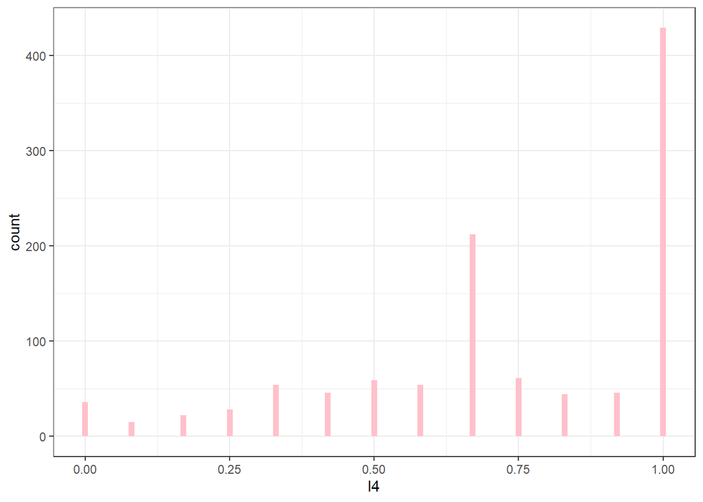

```r
ggplot(data = Base_Trajipaq_Finale_Ok, mapping = aes(x = I4)) +
  geom_histogram(na.rm = TRUE, fill = "pink", binwidth = 0.01) +
  theme_bw()
```

## Q23. Comment est votre état de santé en général ?

1. Très bon
2. Bon
3. Moyen
4. Mauvais
5. Très mauvais
6. Je ne sais pas
7. Je préfère ne pas répondre

Type de variable = factoriel Niveau de mesure = ordinal

```r
Base_Trajipaq_Finale_Ok <-
  Base_Trajipaq_Finale_Ok %>%
  mutate(Q23 = case_when(
    Q23 == 1 ~ 5,
    Q23 == 2 ~ 4,
    Q23 == 3 ~ 3,
    Q23 == 4 ~ 2,
    Q23 == 5 ~ 1,
    Q23 == 98 ~ NA,
    Q23 == 99 ~ NA
  ))
```

```r
freq(Base_Trajipaq_Finale_Ok$Q23)
```

```
## Frequencies
## Base_Trajipaq_Finale_Ok$Q23
## Type: Numeric
##
##               Freq   % Valid   % Valid Cum.   % Total   % Total Cum.
## ----------- ------ --------- -------------- --------- --------------
##           2      4      0.28           0.28      0.26           0.26
##           3     18      1.24           1.52      1.15           1.41
##           4    578     39.94          41.47     36.98          38.39
##           5    847     58.53         100.00     54.19          92.58
##        <NA>    116                               7.42         100.00
##       Total   1563    100.00         100.00    100.00         100.00
```

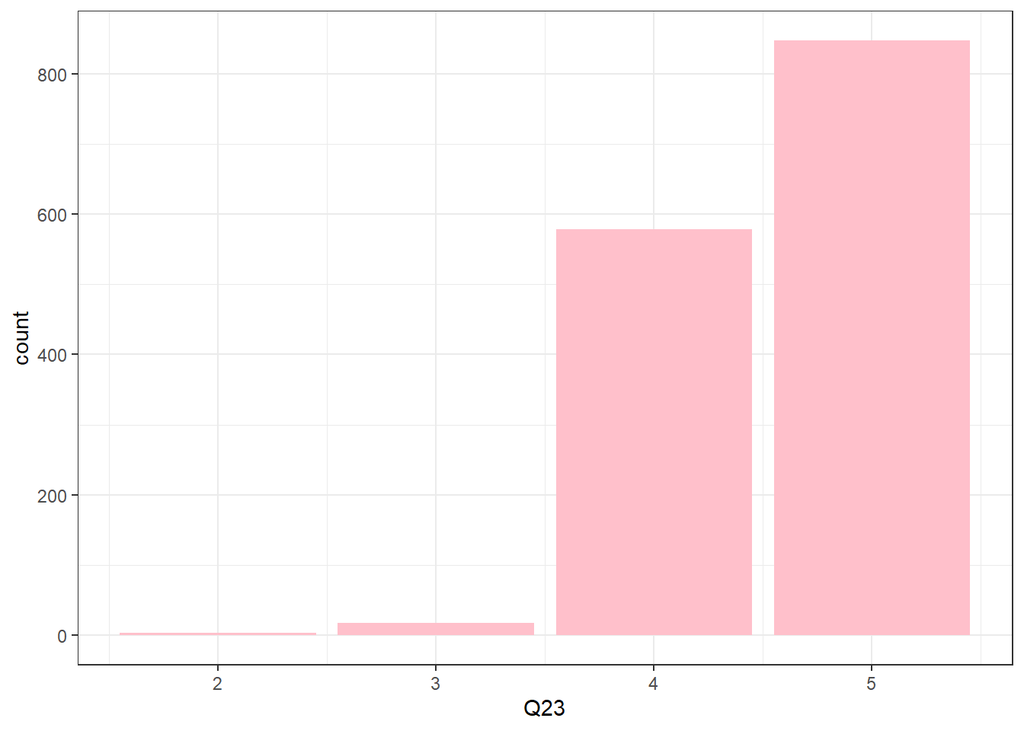

```r
ggplot(data = Base_Trajipaq_Finale_Ok, mapping = aes(x = Q23)) +
  geom_bar(fill = "pink", na.rm = TRUE) +
  theme_bw()
```

## I5. Indice de l’état de santé au cours des 12 derniers mois

```r
Base_Trajipaq_Finale_Ok <-
  Base_Trajipaq_Finale_Ok %>%
  mutate(Q24A = case_when(
    Q24A == 1 ~ 1,
    Q24A == 2 ~ 2,
    Q24A == 96 ~ NA,
    Q24A == 97 ~ NA,
    Q24A == 98 ~ NA,
    Q24A == 99 ~ NA
  ))

Base_Trajipaq_Finale_Ok <-
  Base_Trajipaq_Finale_Ok %>%
  mutate(Q24B = case_when(
    Q24B == 1 ~ 1,
    Q24B == 2 ~ 2,
    Q24B == 96 ~ NA,
    Q24B == 97 ~ NA,
    Q24B == 98 ~ NA,
    Q24B == 99 ~ NA
  ))

Base_Trajipaq_Finale_Ok <-
  Base_Trajipaq_Finale_Ok %>%
  mutate(Q24C = case_when(
    Q24C == 1 ~ 1,
    Q24C == 2 ~ 2,
    Q24C == 96 ~ NA,
    Q24C == 97 ~ NA,
    Q24C == 98 ~ NA,
    Q24C == 99 ~ NA
  ))

Base_Trajipaq_Finale_Ok <-
  Base_Trajipaq_Finale_Ok %>%
  mutate(Q24D = case_when(
    Q24D == 1 ~ 1,
    Q24D == 2 ~ 2,
    Q24D == 96 ~ NA,
    Q24D == 97 ~ NA,
    Q24D == 98 ~ NA,
    Q24D == 99 ~ NA
  ))

Base_Trajipaq_Finale_Ok <-
  Base_Trajipaq_Finale_Ok %>%
  mutate(Q24E = case_when(
    Q24E == 1 ~ 1,
    Q24E == 2 ~ 2,
    Q24E == 96 ~ NA,
    Q24E == 97 ~ NA,
    Q24E == 98 ~ NA,
    Q24E == 99 ~ NA
  ))
```

```r
v_I5 <- c("Q24A",
          "Q24B",
          "Q24C",
          "Q24D",
          "Q24E"
          )

Base_Trajipaq_Finale_Ok <-
  Base_Trajipaq_Finale_Ok %>%
  rowwise() %>%
  mutate(I5 = (sum(c_across(all_of(v_I5)), na.rm = TRUE) - length(v_I5)) / (1*length(v_I5))) %>%
  mutate(I5 = if (I5 < 0) NA_real_ else I5) %>%
  ungroup()
```

```r
descr(Base_Trajipaq_Finale_Ok$I5)
```

```
## Descriptive Statistics
## Base_Trajipaq_Finale_Ok$I5
## N: 1563
##
##                          I5
## ----------------- ---------
##              Mean      0.78
##           Std.Dev      0.29
##               Min      0.00
##                Q1      0.60
##            Median      1.00
##                Q3      1.00
##               Max      1.00
##               MAD      0.00
##               IQR      0.40
##                CV      0.37
##          Skewness     -1.05
##       SE.Skewness      0.06
##          Kurtosis      0.12
##           N.Valid   1430.00
##         Pct.Valid     91.49
```

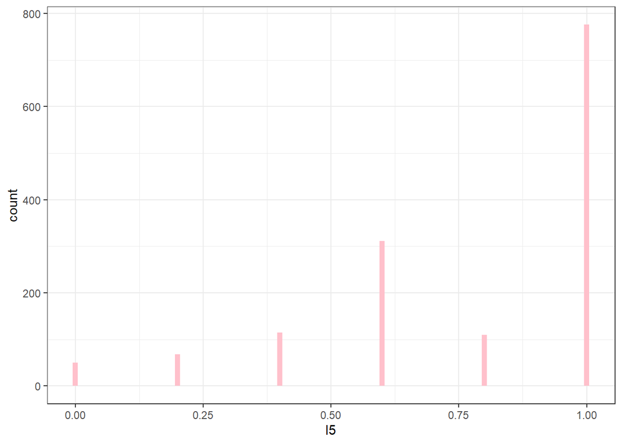

```r
ggplot(data = Base_Trajipaq_Finale_Ok, mapping = aes(x = I5)) +
  geom_histogram(na.rm = TRUE, fill = "pink", binwidth = 0.01) +
  theme_bw()
```

La distribution est asymétrique vers la gauche. L’indice moyen de l’état de santé au cours des 12 derniers mois est de 0.78.

## Q26. Quel était le plus haut diplôme d’études obtenu par votre mère ?

1. Moins que le secondaire
2. Secondaire ou équivalent
3. Collégial
4. Formation professionnelle ou post-secondaire
5. Université
6. Inconnu
7. Je ne sais pas
8. Je préfère ne pas répondre

Type de variable = factoriel Niveau de mesure = ordinal

```r
Base_Trajipaq_Finale_Ok <-
  Base_Trajipaq_Finale_Ok %>%
  mutate(Q26 = case_when(
    Q26 == 1 ~ 1,
    Q26 == 2 ~ 2,
    Q26 == 3 ~ 3,
    Q26 == 4 ~ 4,
    Q26 == 5 ~ 5,
    Q26 == 6 ~ NA,
    Q26 == 98 ~ NA,
    Q26 == 99 ~ NA
  ))
```

```r
freq(Base_Trajipaq_Finale_Ok$Q26)
```

```
## Frequencies
## Base_Trajipaq_Finale_Ok$Q26
## Type: Numeric
##
##               Freq   % Valid   % Valid Cum.   % Total   % Total Cum.
## ----------- ------ --------- -------------- --------- --------------
##           1    238     16.49          16.49     15.23          15.23
##           2    355     24.60          41.09     22.71          37.94
##           3    241     16.70          57.80     15.42          53.36
##           4    196     13.58          71.38     12.54          65.90
##           5    413     28.62         100.00     26.42          92.32
##        <NA>    120                               7.68         100.00
##       Total   1563    100.00         100.00    100.00         100.00
```

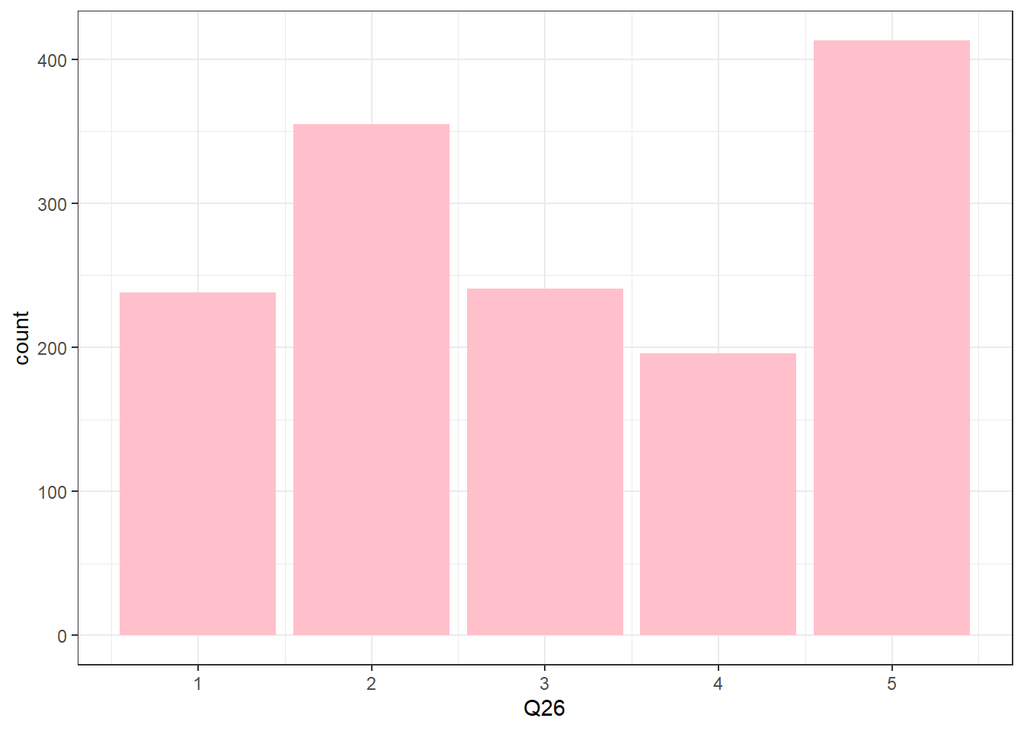

```r
ggplot(data = Base_Trajipaq_Finale_Ok, mapping = aes(x = Q26)) +
  geom_bar(fill = "pink", na.rm = TRUE) +
  theme_bw()
```

La valeur modale est “diplôme universitaire” (28.62%).

## Q28. Quel était le plus haut diplôme d’études obtenu par votre père ?

1. Moins que le secondaire
2. Secondaire ou équivalent
3. Collégial
4. Formation professionnelle ou post-secondaire
5. Université
6. Inconnu
7. Je ne sais pas
8. Je préfère ne pas répondre

Type de variable = factoriel Niveau de mesure = ordinal

```r
Base_Trajipaq_Finale_Ok <-
  Base_Trajipaq_Finale_Ok %>%
  mutate(Q28 = case_when(
    Q28 == 1 ~ 1,
    Q28 == 2 ~ 2,
    Q28 == 3 ~ 3,
    Q28 == 4 ~ 4,
    Q28 == 5 ~ 5,
    Q28 == 6 ~ NA,
    Q28 == 98 ~ NA,
    Q28 == 99 ~ NA
  ))
```

```r
freq(Base_Trajipaq_Finale_Ok$Q28)
```

```
## Frequencies
## Base_Trajipaq_Finale_Ok$Q28
## Type: Numeric
##
##               Freq   % Valid   % Valid Cum.   % Total   % Total Cum.
## ----------- ------ --------- -------------- --------- --------------
##           1    206     14.56          14.56     13.18          13.18
##           2    288     20.35          34.91     18.43          31.61
##           3    201     14.20          49.12     12.86          44.47
##           4    229     16.18          65.30     14.65          59.12
##           5    491     34.70         100.00     31.41          90.53
##        <NA>    148                               9.47         100.00
##       Total   1563    100.00         100.00    100.00         100.00
```

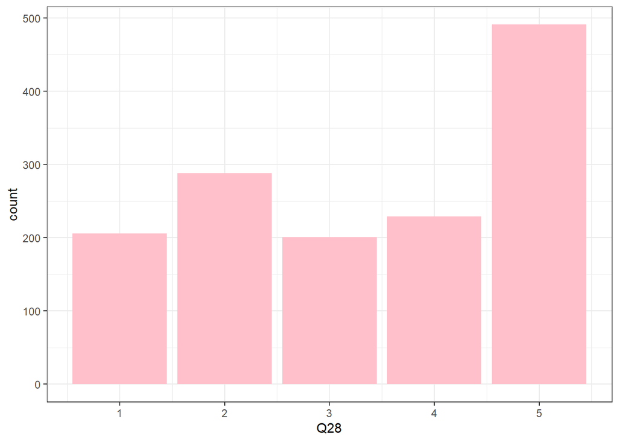

```r
ggplot(data = Base_Trajipaq_Finale_Ok, mapping = aes(x = Q28)) +
  geom_bar(fill = "pink", na.rm = TRUE) +
  theme_bw()
```

La valeur modale est “diplôme universitaire” (34.70%).